# Discussion Section Worksheet #4

Anupama Bhatta

October 3, 2023

# Learning objectives

- Practice calculating and interpreting summary statistics
- Visualize relationships between variables in a dataset
- Calculate the correlation between two variables and interpret it

# What makes a board game popular?

Contemporary board games provide a face to face experience rich in analytic opportunities and can spur discussions about UX design in the rules, materials, and game mechanics. Our data set comes from the popular board game site https://boardgamegeek.com, a resource used for reviewing and discussing board games. Board Game Geek (BGG) serves as a hub for players to come together and gather data for other players to reference as they search out new and novel play experiences. This data set can help reveal some design choices that are favored by the board game community at large.

Copy the file 'bgg_2018.csv' into your working directory and let's get started.

## Read in the dataset

```r
library(tidyverse)
# uncomment the code to run it
game_data <- read_csv('bgg_2018.csv')
```

## Explore the dataset

By dataset, we mean `game_data` as a dataframe. When exploring, look at the column titles.

```r
# uncomment this code and run it
glimpse(game_data)
```

```
## Rows: 4,999
## Columns: 20
## $ rank        <dbl> 1, 2, 3, 4, 5, 6, 7, 8, 9, 10, 11, 12, 13, 14, 15, 16, 17,…
## $ bgg_url     <chr> "https://boardgamegeek.com/boardgame/174430/gloomhaven", "…
## $ game_id     <dbl> 174430, 161936, 182028, 12333, 167791, 187645, 120677, 169…
## $ names       <chr> "Gloomhaven", "Pandemic Legacy: Season 1", "Through the Ag…
## $ min_players <dbl> 1, 2, 2, 2, 1, 2, 2, 1, 2, 2, 2, 2, 1, 2, 1, 1, 2, 1, 1, 2…
## $ max_players <dbl> 4, 4, 4, 2, 5, 4, 5, 5, 2, 4, 4, 4, 7, 5, 5, 4, 4, 2, 5, 4…
## $ avg_time    <dbl> 150, 60, 240, 180, 120, 240, 150, 115, 30, 150, 90, 180, 2…
## $ min_time    <dbl> 90, 60, 180, 120, 120, 180, 60, 90, 30, 75, 30, 150, 30, 9…
## $ max_time    <dbl> 150, 60, 240, 180, 120, 240, 150, 115, 30, 150, 90, 180, 2…
## $ year        <dbl> 2017, 2015, 2015, 2005, 2016, 2016, 2012, 2016, 2015, 2016…
## $ avg_rating  <dbl> 9.01310, 8.66575, 8.65702, 8.35188, 8.38331, 8.50113, 8.26…
## $ geek_rating <dbl> 8.52234, 8.49837, 8.32401, 8.21012, 8.17328, 8.16882, 8.12…
## $ num_votes   <dbl> 9841, 23489, 10679, 29923, 20468, 11779, 27621, 24598, 282…
## $ image_url   <chr> "https://cf.geekdo-images.com/images/pic2437871.jpg", "htt…
## $ age         <dbl> 12, 13, 14, 13, 12, 14, 12, 14, 10, 12, 12, 13, 12, 12, 12…
## $ mechanic    <chr> "Action / Movement Programming, Co-operative Play, Grid Mo…
## $ owned       <dbl> 18217, 38105, 14147, 41094, 26145, 18673, 31318, 32621, 44…
## $ category    <chr> "Adventure, Exploration, Fantasy, Fighting, Miniatures", "…
## $ designer    <chr> "Isaac Childres", "Rob Daviau, Matt Leacock", "Vlaada Chv\…
## $ weight      <dbl> 3.7720, 2.8056, 4.3538, 3.5446, 3.2465, 3.6067, 3.9429, 3.…
```

Describe the shape of the distribution of ratings for the games in the dataset. (Do this for both avg_rating and geek_rating). Find the mean and median for avg_rating and geek_rating, then discuss which metric is an appropriate measure of the center for each distribution.

```r
# What's the mean and median for avg_rating?
summary(game_data$avg_rating)
```

```
##    Min. 1st Qu.  Median    Mean 3rd Qu.    Max.
##   5.773   6.528   6.897   6.955   7.332   9.264
```

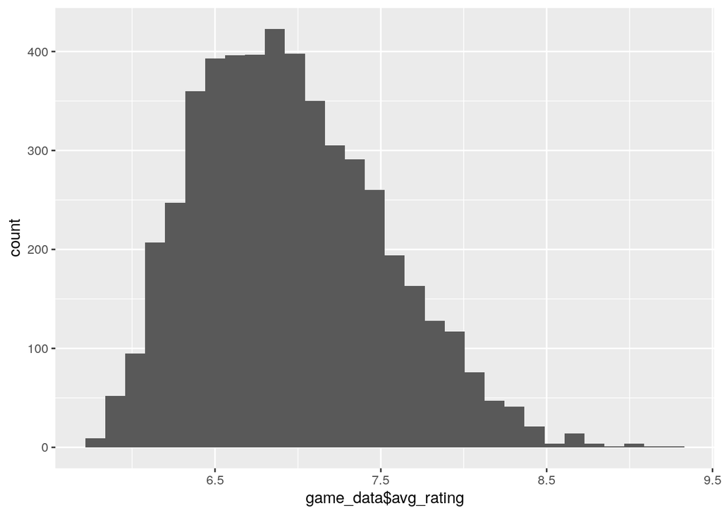

```r
ggplot(game_data, mapping = aes(x = game_data$avg_rating))+
   geom_histogram()
```

```r
# How about geek_rating?
summary(game_data$geek_rating)
```

```
##    Min. 1st Qu.  Median    Mean 3rd Qu.    Max.
##   5.636   5.721   5.901   6.083   6.290   8.522
```

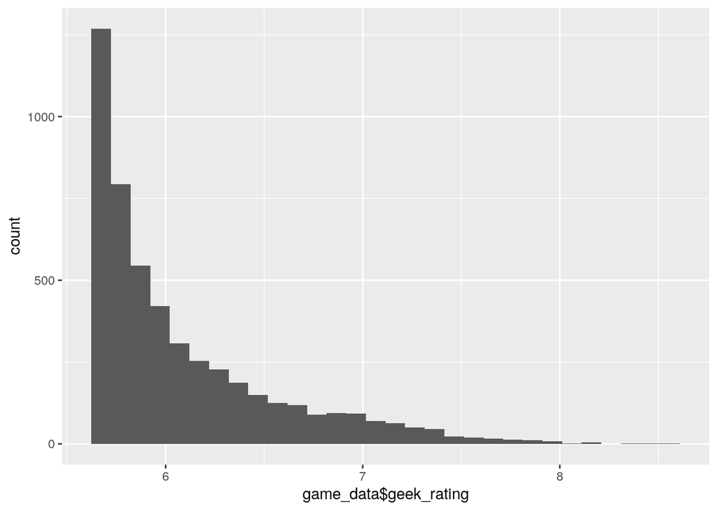

```r
ggplot(game_data, mapping = aes(x = game_data$geek_rating))+
   geom_histogram()
```

Based on the histograms for both variables, I would say that the median value is more appropriate for describing typical rating values as the median value is less likely to be skewed by outliers as opposed to the mean value.

## Does there seem to be a relationship between geek_rating and avg_rating?

Let's visualize them on a scatter plot to understand. Put geek_rating on the x-axis.

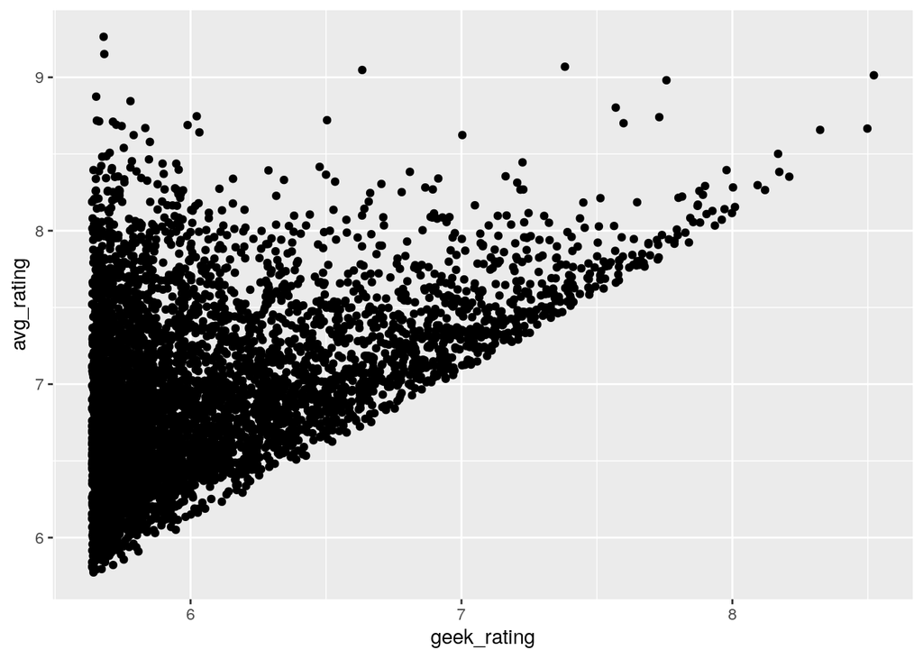

```r
# let's create a scatter plot
ggplot(game_data, mapping = aes(x=geek_rating, y=avg_rating))+
  geom_point()
```

There might be some overplotting. Try adding jitter to the plot.

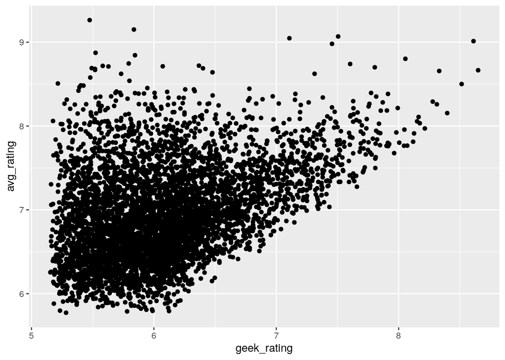

```r
# how about trying jitter to deal with overplotting?
ggplot(game_data, mapping = aes(x=geek_rating, y=avg_rating))+
  geom_jitter(width = 0.5)
```

What can you say about the relationship based on the above graphs?

Based on the scatterplots, I would that that there is a distinct postive relationship between geek_rating and avg_rating.

## Examine the top 50 games

```r
# get top 50 games.
# we recommend saving this result in a variable called "top_50_games".
top_50_games <- game_data %>%
  top_n(n = -50, wt = rank)

top_50_games
```

```
## # A tibble: 50 × 20
##     rank bgg_url     game_id names min_p…¹ max_p…² avg_t…³ min_t…⁴ max_t…⁵  year
##    <dbl> <chr>         <dbl> <chr>   <dbl>   <dbl>   <dbl>   <dbl>   <dbl> <dbl>
##  1     1 https://bo…  174430 Gloo…       1       4     150      90     150  2017
##  2     2 https://bo…  161936 Pand…       2       4      60      60      60  2015
##  3     3 https://bo…  182028 Thro…       2       4     240     180     240  2015
##  4     4 https://bo…   12333 Twil…       2       2     180     120     180  2005
##  5     5 https://bo…  167791 Terr…       1       5     120     120     120  2016
##  6     6 https://bo…  187645 Star…       2       4     240     180     240  2016
##  7     7 https://bo…  120677 Terr…       2       5     150      60     150  2012
##  8     8 https://bo…  169786 Scyt…       1       5     115      90     115  2016
##  9     9 https://bo…  173346 7 Wo…       2       2      30      30      30  2015
## 10    10 https://bo…  193738 Grea…       2       4     150      75     150  2016
## # … with 40 more rows, 10 more variables: avg_rating <dbl>, geek_rating <dbl>,
## #   num_votes <dbl>, image_url <chr>, age <dbl>, mechanic <chr>, owned <dbl>,
## #   category <chr>, designer <chr>, weight <dbl>, and abbreviated variable
## #   names ¹min_players, ²max_players, ³avg_time, ⁴min_time, ⁵max_time
## # ℹ Use `print(n = ...)` to see more rows, and `colnames()` to see all variable names
```

Now, visualize how the ratings vary by the number of players. You'll want to use boxplots to do this. Hint: you might need to convert the number of players variable to a factor. There's an example of this in Modern Dive Chapter 2, Boxplots section!

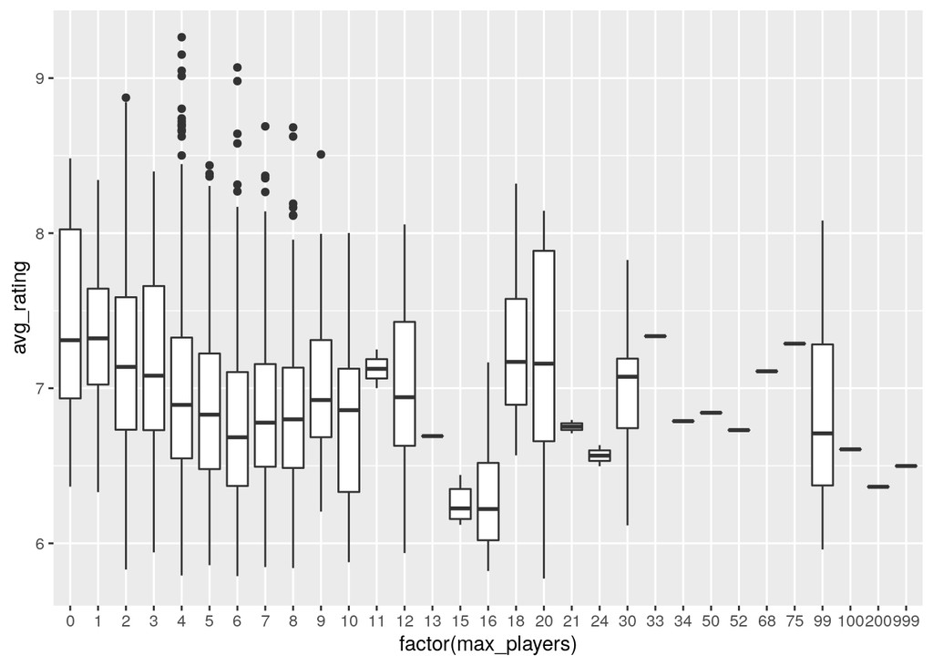

```r
# how does the rating (avg_rating) vary with number of players?
# make a boxplot
ggplot(game_data, mapping = aes(x = factor(max_players), y = avg_rating))+
  geom_boxplot()
```

Finally, repeat this type of visualization except to show how ratings vary by AGE.

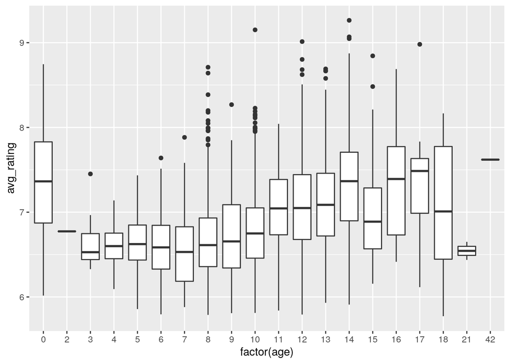

```r
# how does the rating vary with age?
# make a boxplot
ggplot(game_data, mapping = aes(x = factor(age), y = avg_rating))+
  geom_boxplot()
```

### Calculate some summary statistics.

```r
# minimum rating
min(game_data$avg_rating)
```

```
## [1] 5.77286
```

```r
# maximum rating
max(game_data$avg_rating)
```

```
## [1] 9.26384
```

```r
# median rating
median(game_data$avg_rating)
```

```
## [1] 6.89685
```

```r
# 25th percentile
quantile(game_data$avg_rating, probs = 0.25)
```

```
##     25%
## 6.52822
```

```r
# 75th percentile
quantile(game_data$avg_rating, probs = 0.75)
```

```
##     75%
## 7.33218
```

```r
# Interquartile range (IQR)
IQR(game_data$avg_rating)
```

```
## [1] 0.80396
```

```r
# Standard deviation
sd(game_data$avg_rating)
```

```
## [1] 0.5610708
```

## Make and test a hypothesis

Finally, looking at the whole dataset, create a hypothesis about how you expect two *numerical* variables to be related. Are games for younger ages going to be rated higher? Are newer board games going to be rated lower? Pick two variables and make a hypothesis.

I will hypothesize that age and avg_time are going to be positively correlated, meaning that older people are going have a higer average game time value than younger people.

Then, make a scatterplot that helps you begin to evaluate that hypothesis.

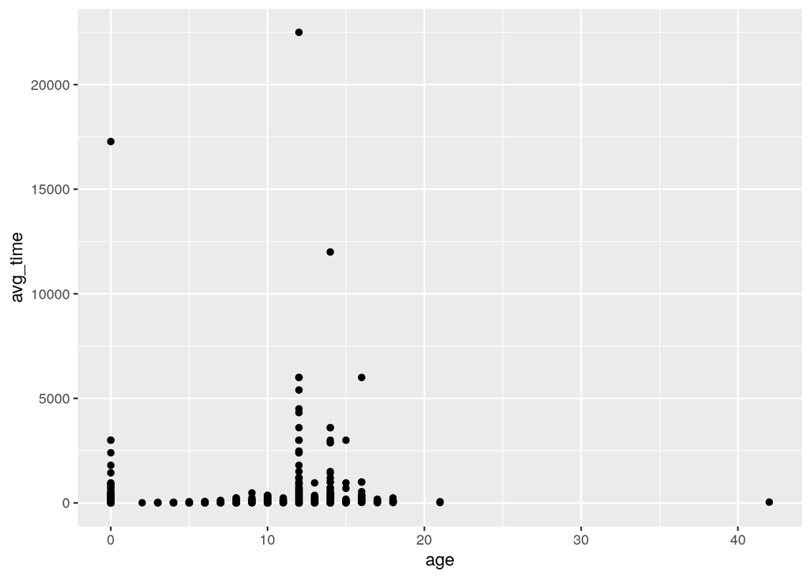

```r
ggplot(game_data, mapping = aes(x=age, y=avg_time))+
  geom_point()
```

### Add a line of best firt to your model.

In Chapter 5, we see examples of plotting a "line of best fit" over a scatterplot. Do this to the scatterplot you just made.

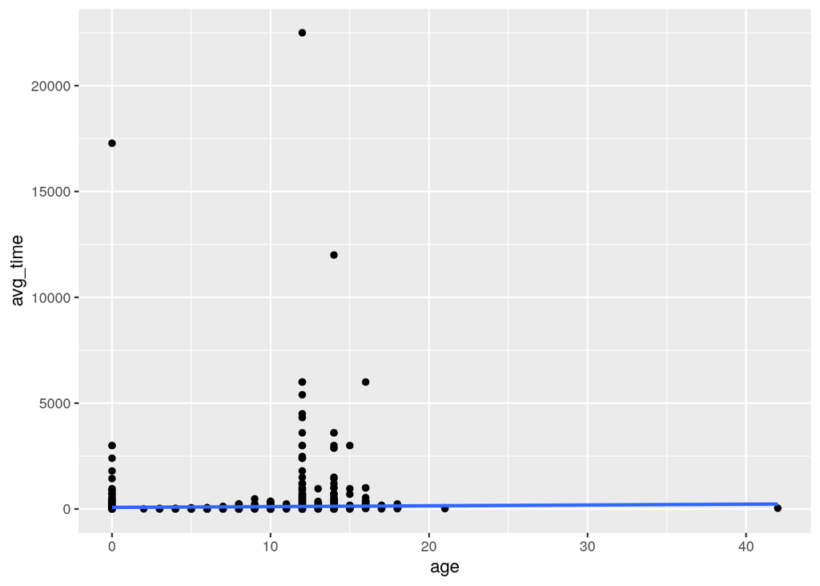

```r
ggplot(game_data, mapping = aes(x=age, y=avg_time))+
  geom_point()+
  geom_smooth(method='lm', se = FALSE)
```

### Calculate the correlation between your variables.

Now, calculate the correlation between your two variables (there is a code example of this in Chapter 5, too).

```r
cor(game_data$age, game_data$avg_time)
```

```
## [1] 0.02451662
```

### Interpret the relationship

Based on your visualization and the correlation you just calculated:

A. What is the relationship between your two variables? Do they trend together? If yes, is it a postive or negative relationship?

B. What might explain this relationship?